# STA302 Project Part 1 – Code

Sale price of new single-family homes (Census SOC 2025): floor area x Census division

Group 62

November 02, 2026

This file reproduces every number, table and figure in our Part 1 proposal. It uses only base R plus the `car` package (for Levene’s test). Place it in the project folder next to `data/` and `figures/` and knit; all paths are relative.

**Research question.** Among newly built, detached single-family homes sold in the United States in 2025, how much does additional finished floor area add to the sale price, and does this marginal price of floor area differ across the nine Census divisions, after accounting for lot size, room counts, garage, foundation, exterior wall material, heating fuel and the other structural features listed below?

```r
library(car)      # leveneTest() only
set.seed(302)     # no random numbers are drawn below; the train/test split is read from a file (Section 5)
dir.create("figures", showWarnings = FALSE)
dir.create("data/cleaned", showWarnings = FALSE, recursive = TRUE)
```

# 1 Read the original data

The original file is the 2025 annual microdata file of the U.S. Census Bureau’s Survey of Construction (SOC), downloaded from https://www.census.gov/construction/chars/microdata.html (`soc25.xlsx`, saved as CSV without any other change). Variable definitions are in `data/original/socmicro_info.pdf`.

```r
raw <- read.csv("data/original/soc25.csv")
dim(raw)
```

```
#> [1] 25246    61
```

# 2 Cleaning: one filter at a time

Each step below prints the number of rows that remain. The codes used come from `socmicro_info.pdf` (for example, `0` or `9` means “not reported” for the categorical fields).

```r
clean_soc <- function(raw, year) {
  steps <- data.frame(step = character(0), rows_remaining = integer(0))
  add <- function(label, d) {
    steps[nrow(steps) + 1, ] <<- list(label, nrow(d))
    d
  }
  s <- add(sprintf("All %d SOC records", year), raw)
  s <- add("CAT = 1 (house built for sale)", s[s$CAT == 1, ])
  s <- add(sprintf("Sales contract signed in %d", year),
           s[s$SALE >= year * 100 + 1 & s$SALE <= year * 100 + 12, ])
  s <- add("Sale price reported (SLPR > 0)", s[s$SLPR > 0, ])
  s <- add("Detached (DET = 1) and not in a condominium project (CON = 2)",
           s[s$DET == 1 & s$CON == 2, ])
  s <- add("Floor area and lot size reported (SQFS > 0, AREA > 0)",
           s[s$SQFS > 0 & s$AREA > 0, ])
  # valid (reported) codes of the 12 categorical source fields
  valid <- list(STOR = 1:3, BEDR = 2:5, FULB = 1:4, HAFB = 0:2, GAR = 1:4, BASE = 1:4,
                FPLS = 0:2, ASSOC = 1:2, AGER = 1:2, WAL1 = c(1, 2, 4:9), FUEL = 1:5,
                SEWER = 1:3)
  ok <- rep(TRUE, nrow(s))
  for (v in names(valid)) ok <- ok & s[[v]] %in% valid[[v]]
  s <- add("No 'not reported' code in any categorical predictor", s[ok, ])
  list(data = s, steps = steps)
}

cl <- clean_soc(raw, 2025)
cl$steps
```

```
#>                                                            step rows_remaining
#> 1                                          All 2025 SOC records          25246
#> 2                                CAT = 1 (house built for sale)          16849
#> 3                                 Sales contract signed in 2025           8901
#> 4                                Sale price reported (SLPR > 0)           8532
#> 5 Detached (DET = 1) and not in a condominium project (CON = 2)           7062
#> 6         Floor area and lot size reported (SQFS > 0, AREA > 0)           6315
#> 7           No 'not reported' code in any categorical predictor           6185
```

```r
stopifnot(nrow(cl$data) == 6185)
```

# 3 Construct the analysis variables

- `price_k`: sale price in $1,000s (SLPR / 1000; the price includes the improved lot).
- `sqft100`: finished floor area in 100s of square feet (SQFS / 100).
- `lot_k`: lot size in 1,000s of square feet (AREA / 1000).
- `sale_month`: month the sales contract was signed (1–12).
- `stage`: construction stage when the contract was signed, derived from the sale, start and completion dates only (never from the price).
- Categorical predictors are recoded to readable labels; the first level listed is the reference level. WAL1 “concrete block” (code 6) is grouped with “other” (code 9); FUEL “oil” (4) is grouped with “other/no heat” (5); SEWER “other” (3, six houses) is grouped with individual septic systems (2).
- `slpr_flag` (price top/bottom-coded by the Census Bureau) and `weight` (sampling weight) are kept for later sensitivity checks; they are **not** predictors.

```r
recode <- function(x, map) unname(map[as.character(x)])
ym <- function(x) (x %/% 100) * 12 + x %% 100            # YYYYMM -> month count

division_levels <- c("SouthAtlantic", "NewEngland", "MidAtlantic", "ENCentral", "WNCentral",
                     "ESCentral", "WSCentral", "Mountain", "Pacific")
factor_levels <- list(
  division = division_levels,
  stories = c("1", "2", "3plus"),
  bedrooms = c("2orless", "3", "4", "5plus"),
  fullbath = c("1orless", "2", "3", "4plus"),
  halfbath = c("0", "1", "2plus"),
  garage = c("1car", "2car", "3plus", "other"),
  foundation = c("basement", "crawl", "slab", "other"),
  fireplace = c("0", "1", "2plus"),
  hoa = c("no", "yes"),
  age_restricted = c("no", "yes"),
  wall = c("brick", "wood", "stucco", "vinyl", "stone", "fibercement", "other"),
  heat_fuel = c("electric", "gas", "propane", "other"),
  sewer = c("public", "septic"),
  stage = c("completed", "under_constr", "not_started"))

construct_soc <- function(s) {
  sale_m <- ym(s$SALE)
  strt_m <- ifelse(s$STRT > 0, ym(s$STRT), 1e9)
  comp_m <- ifelse(s$COMP > 0, ym(s$COMP), 1e9)
  data.frame(
    id = s$ID,
    price_k = s$SLPR / 1000,
    sqft100 = s$SQFS / 100,
    lot_k = s$AREA / 1000,
    division = recode(s$DIV, c("1" = "NewEngland", "2" = "MidAtlantic", "3" = "ENCentral",
                               "4" = "WNCentral", "5" = "SouthAtlantic", "6" = "ESCentral",
                               "7" = "WSCentral", "8" = "Mountain", "9" = "Pacific")),
    stories = recode(s$STOR, c("1" = "1", "2" = "2", "3" = "3plus")),
    bedrooms = recode(s$BEDR, c("2" = "2orless", "3" = "3", "4" = "4", "5" = "5plus")),
    fullbath = recode(s$FULB, c("1" = "1orless", "2" = "2", "3" = "3", "4" = "4plus")),
    halfbath = recode(s$HAFB, c("0" = "0", "1" = "1", "2" = "2plus")),
    garage = recode(s$GAR, c("1" = "1car", "2" = "2car", "3" = "3plus", "4" = "other")),
    foundation = recode(s$BASE, c("1" = "basement", "2" = "crawl", "3" = "slab", "4" = "other")),
    fireplace = recode(s$FPLS, c("0" = "0", "1" = "1", "2" = "2plus")),
    hoa = recode(s$ASSOC, c("1" = "yes", "2" = "no")),
    age_restricted = recode(s$AGER, c("1" = "yes", "2" = "no")),
    wall = recode(s$WAL1, c("1" = "wood", "2" = "brick", "4" = "stucco", "5" = "vinyl",
                            "6" = "other", "7" = "stone", "8" = "fibercement", "9" = "other")),
    heat_fuel = recode(s$FUEL, c("1" = "electric", "2" = "gas", "3" = "propane",
                                 "4" = "other", "5" = "other")),
    sewer = recode(s$SEWER, c("1" = "public", "2" = "septic", "3" = "septic")),
    sale_month = s$SALE %% 100,
    stage = ifelse(sale_m < strt_m, "not_started",
                   ifelse(sale_m < comp_m, "under_constr", "completed")),
    slpr_flag = s$SLPR_F,
    weight = s$WEIGHT,
    stringsAsFactors = FALSE)
}

as_model_factors <- function(d) {
  for (v in names(factor_levels)) d[[v]] <- factor(d[[v]], levels = factor_levels[[v]])
  d
}

soc <- construct_soc(cl$data)
stopifnot(!anyNA(soc), !anyDuplicated(soc$id))
dim(soc)
```

```
#> [1] 6185   21
```

# 4 Attach the archived train/test split and write the cleaned file

The 70/30 train/test split was fixed **once, at the start of the project, and archived** in `data/split_ids.csv` (columns `id`, `split`). It was produced in Python with `numpy.random.default_rng(302).permutation(6185)` applied to the rows of the cleaned data in the order above, with the first 4,330 permuted rows forming the training set. We read the archived file instead of re-drawing the split in R (`set.seed(302)` in R would give a different split). This guarantees that the test set is the same one that was set aside before any modelling and that it has never been looked at: every table, figure and model in this file uses the training rows only.

```r
split_ids <- read.csv("data/split_ids.csv")
stopifnot(nrow(split_ids) == nrow(soc), setequal(split_ids$id, soc$id))
soc$split <- split_ids$split[match(soc$id, split_ids$id)]
table(soc$split)
```

```
#>
#>  test train
#>  1855  4330
```

```r
write.csv(soc, "data/cleaned/soc_clean.csv", row.names = FALSE)
```

# 5 Keep the training set only

```r
train <- as_model_factors(soc[soc$split == "train", ])
nrow(train)
```

```
#> [1] 4330
```

# 6 Variable summary (training set, n = 4,330)

Skewness is the moment coefficient $g_1 = m_3 / m_2^{3/2}$. After cleaning no variable has missing values (rows with “not reported” codes were removed in Section 2).

```r
skew <- function(x) { z <- x - mean(x); mean(z^3) / mean(z^2)^1.5 }
exkurt <- function(x) { z <- x - mean(x); mean(z^4) / mean(z^2)^2 - 3 }

num_vars <- c(price_k = "Response: sale price ($1000s)",
              sqft100 = "Finished floor area (100 sq ft)",
              lot_k = "Lot size (1000 sq ft)",
              sale_month = "Month contract signed (1-12)")
num_tab <- data.frame(
  variable = names(num_vars), description = unname(num_vars),
  mean = sapply(names(num_vars), function(v) mean(train[[v]])),
  sd = sapply(names(num_vars), function(v) sd(train[[v]])),
  min = sapply(names(num_vars), function(v) min(train[[v]])),
  median = sapply(names(num_vars), function(v) median(train[[v]])),
  max = sapply(names(num_vars), function(v) max(train[[v]])),
  skewness = sapply(names(num_vars), function(v) skew(train[[v]])),
  missing = sapply(names(num_vars), function(v) sum(is.na(train[[v]]))),
  row.names = NULL)
knitr::kable(num_tab, digits = 2, caption = "Numerical variables (training set)")
```

Numerical variables (training set)

| variable | description | mean | sd | min | median | max | skewness | missing |
| --- | --- | --- | --- | --- | --- | --- | --- | --- |
| price_k | Response: sale price ($1000s) | 526.97 | 307.41 | 209.90 | 433.0 | 3300.00 | 3.04 | 0 |
| sqft100 | Finished floor area (100 sq ft) | 25.45 | 9.95 | 7.11 | 23.0 | 85.07 | 1.67 | 0 |
| lot_k | Lot size (1000 sq ft) | 14.06 | 16.56 | 2.00 | 8.7 | 87.12 | 3.10 | 0 |
| sale_month | Month contract signed (1-12) | 6.28 | 3.42 | 1.00 | 6.0 | 12.00 | 0.09 | 0 |

```r
cat_vars <- names(factor_levels)
cat_tab <- data.frame(
  variable = cat_vars,
  levels = sapply(cat_vars, function(v) nlevels(train[[v]])),
  counts = sapply(cat_vars, function(v) {
    tb <- table(train[[v]]); paste(names(tb), tb, sep = ": ", collapse = "; ")
  }),
  missing = sapply(cat_vars, function(v) sum(is.na(train[[v]]))),
  row.names = NULL)
knitr::kable(cat_tab, caption = "Categorical variables (training set; first level = reference)")
```

Categorical variables (training set; first level = reference)

| variable | levels | counts | missing |
| --- | --- | --- | --- |
| division | 9 | SouthAtlantic: 1308; NewEngland: 39; MidAtlantic: 119; ENCentral: 510; WNCentral: 313; ESCentral: 344; WSCentral: 850; Mountain: 473; Pacific: 374 | 0 |
| stories | 3 | 1: 2120; 2: 2116; 3plus: 94 | 0 |
| bedrooms | 4 | 2orless: 154; 3: 1780; 4: 1777; 5plus: 619 | 0 |
| fullbath | 4 | 1orless: 46; 2: 2664; 3: 1203; 4plus: 417 | 0 |
| halfbath | 3 | 0: 2373; 1: 1897; 2plus: 60 | 0 |
| garage | 4 | 1car: 158; 2car: 3124; 3plus: 919; other: 129 | 0 |
| foundation | 4 | basement: 992; crawl: 403; slab: 2926; other: 9 | 0 |
| fireplace | 3 | 0: 2781; 1: 1383; 2plus: 166 | 0 |
| hoa | 2 | no: 1109; yes: 3221 | 0 |
| age_restricted | 2 | no: 4216; yes: 114 | 0 |
| wall | 7 | brick: 897; wood: 169; stucco: 906; vinyl: 1362; stone: 56; fibercement: 926; other: 14 | 0 |
| heat_fuel | 4 | electric: 2147; gas: 2083; propane: 52; other: 48 | 0 |
| sewer | 2 | public: 3893; septic: 437 | 0 |
| stage | 3 | completed: 2452; under_constr: 1344; not_started: 534 | 0 |

Additional facts used in the proposal caption:

```r
c(price_excess_kurtosis = exkurt(train$price_k),
  share_price_top_or_bottom_coded = mean(train$slpr_flag == 1),
  lot_at_topcode_87.12 = sum(train$lot_k == 87.12),
  lot_at_bottomcode_2.0 = sum(train$lot_k == 2),
  sqft100_p10 = unname(quantile(train$sqft100, 0.10, type = 7)),
  sqft100_p90 = unname(quantile(train$sqft100, 0.90, type = 7)))
```

```
#>           price_excess_kurtosis share_price_top_or_bottom_coded            lot_at_topcode_87.12
#>                     15.87632111                      0.07113164                     93.00000000
#>           lot_at_bottomcode_2.0                     sqft100_p10                     sqft100_p90
#>                     39.00000000                     16.00000000                     38.00000000
```

```r
# Draw a figure once into figures/<name> (used by the proposal) and once into this document.
fig_out <- function(name, width, height, draw) {
  png(file.path("figures", name), width = width, height = height, units = "in", res = 200)
  draw()
  invisible(dev.off())
  draw()
}
pt_col <- adjustcolor("#33658a", alpha.f = 0.25)
ln_col <- "#d1495b"
div_col <- c(SouthAtlantic = "#000000", NewEngland = "#E69F00", MidAtlantic = "#56B4E9",
             ENCentral = "#009E73", WNCentral = "#B8860B", ESCentral = "#0072B2",
             WSCentral = "#D55E00", Mountain = "#CC79A7", Pacific = "#7F7F7F")
div_lty <- setNames(rep(1:3, 3), division_levels)
div_lab <- c(SouthAtlantic = "South Atlantic", NewEngland = "New England", MidAtlantic = "Middle Atlantic",
             ENCentral = "East North Central", WNCentral = "West North Central",
             ESCentral = "East South Central", WSCentral = "West South Central",
             Mountain = "Mountain", Pacific = "Pacific")
```

# 7 Why an interaction between floor area and division?

Hedonic price theory (Rosen, 1974) treats the slope of price on a characteristic as that characteristic’s implicit price, which is set in each market separately; construction costs (Gyourko & Saiz, 2006) and regulation (Glaeser, Gyourko & Saks, 2005) differ across U.S. regions. The figure below shows that the simple (unadjusted) slope of price on floor area differs clearly across divisions in the training data.

```r
within_slopes <- t(sapply(division_levels, function(g) {
  fit <- lm(price_k ~ sqft100, data = train[train$division == g, ])
  ci <- confint(fit)["sqft100", ]
  c(n = sum(train$division == g), slope = unname(coef(fit)["sqft100"]),
    lower = unname(ci[1]), upper = unname(ci[2]))
}))
round(within_slopes, 2)
```

```
#>                  n slope lower upper
#> SouthAtlantic 1308 20.47 19.62 21.33
#> NewEngland      39 31.63 24.46 38.81
#> MidAtlantic    119 32.27 23.34 41.21
#> ENCentral      510 13.18 12.09 14.27
#> WNCentral      313 16.83 15.33 18.33
#> ESCentral      344 23.36 21.44 25.28
#> WSCentral      850 17.91 17.14 18.68
#> Mountain       473 20.92 19.30 22.53
#> Pacific        374 29.48 27.00 31.95
```

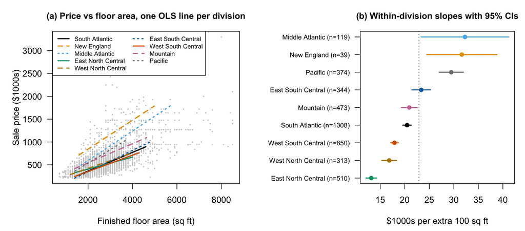

```r
draw_interaction <- function() {
  layout(matrix(1:2, 1), widths = c(1, 1.1))
  par(mar = c(4.5, 5, 3, 1), las = 1)
  plot(train$sqft100 * 100, train$price_k, pch = 16, cex = 0.35, col = "grey80",
       xlab = "Finished floor area (sq ft)", ylab = "Sale price ($1000s)",
       main = "(a) Price vs floor area, one OLS line per division", cex.main = 1)
  for (g in division_levels) {
    dg <- train[train$division == g, ]
    fit <- lm(price_k ~ sqft100, data = dg)
    xs <- quantile(dg$sqft100, c(0.05, 0.95))
    lines(xs * 100, coef(fit)[1] + coef(fit)[2] * xs, col = div_col[g], lty = div_lty[g], lwd = 2.2)
  }
  legend("topleft", legend = div_lab[division_levels], col = div_col, lty = div_lty, lwd = 2,
         cex = 0.7, bg = "white", ncol = 2)
  o <- order(within_slopes[, "slope"])
  k <- length(o)
  par(mar = c(4.5, 10.5, 3, 1))
  plot(within_slopes[o, "slope"], seq_len(k), xlim = range(within_slopes[, c("lower", "upper")]),
       pch = 19, col = div_col[rownames(within_slopes)[o]], yaxt = "n", ylab = "",
       xlab = "$1000s per extra 100 sq ft",
       main = "(b) Within-division slopes with 95% CIs", cex.main = 1)
  segments(within_slopes[o, "lower"], seq_len(k), within_slopes[o, "upper"], seq_len(k),
           col = div_col[rownames(within_slopes)[o]], lwd = 2)
  axis(2, at = seq_len(k), labels = sprintf("%s (n=%d)", div_lab[rownames(within_slopes)[o]],
                                            within_slopes[o, "n"]), las = 1, cex.axis = 0.75)
  abline(v = mean(within_slopes[, "slope"]), lty = 3, col = "grey40")
}
fig_out("fig1_interaction.png", 10, 4.4, draw_interaction)
```

# 8 Preliminary model (Part 1): raw sale price, 17 predictors

Seventeen predictors: 3 numerical (`sqft100`, `lot_k`, `sale_month`) and 14 categorical (`division` and 13 structural/market features), plus the `sqft100 x division` interaction; 52 coefficients. **No transformation or other correction is applied in Part 1.**

```r
f1 <- price_k ~ sqft100 * division + lot_k + stories + bedrooms + fullbath + halfbath + garage +
  foundation + fireplace + hoa + age_restricted + wall + heat_fuel + sewer + stage + sale_month
m1 <- lm(f1, data = train)
s1 <- summary(m1)
c(n = nobs(m1), coefficients = length(coef(m1)), R2 = s1$r.squared, adj_R2 = s1$adj.r.squared,
  sigma = s1$sigma, F = unname(s1$fstatistic[1]), df1 = unname(s1$fstatistic[2]),
  df2 = unname(s1$fstatistic[3]))
```

```
#>            n coefficients           R2       adj_R2        sigma            F          df1          df2
#> 4330.0000000   52.0000000    0.7132610    0.7098427  165.5921042  208.6566948   51.0000000 4278.0000000
```

```r
# does the interaction matter? (nested F tests)
m1_noint <- update(m1, . ~ . - sqft100:division)
m1_noX   <- update(m1, . ~ . - sqft100:division - sqft100)
anova(m1_noint, m1)          # partial F for the 8 interaction coefficients
```

```
#> Analysis of Variance Table
#>
#> Model 1: price_k ~ sqft100 + division + lot_k + stories + bedrooms + fullbath +
#>     halfbath + garage + foundation + fireplace + hoa + age_restricted +
#>     wall + heat_fuel + sewer + stage + sale_month
#> Model 2: price_k ~ sqft100 * division + lot_k + stories + bedrooms + fullbath +
#>     halfbath + garage + foundation + fireplace + hoa + age_restricted +
#>     wall + heat_fuel + sewer + stage + sale_month
#>   Res.Df       RSS Df Sum of Sq      F    Pr(>F)
#> 1   4286 125482247
#> 2   4278 117305947  8   8176300 37.272 < 2.2e-16 ***
#> ---
#> Signif. codes:  0 '***' 0.001 '**' 0.01 '*' 0.05 '.' 0.1 ' ' 1
```

```r
anova(m1_noX, m1)            # partial F for floor area and its interaction (9 coefficients)
```

```
#> Analysis of Variance Table
#>
#> Model 1: price_k ~ division + lot_k + stories + bedrooms + fullbath +
#>     halfbath + garage + foundation + fireplace + hoa + age_restricted +
#>     wall + heat_fuel + sewer + stage + sale_month
#> Model 2: price_k ~ sqft100 * division + lot_k + stories + bedrooms + fullbath +
#>     halfbath + garage + foundation + fireplace + hoa + age_restricted +
#>     wall + heat_fuel + sewer + stage + sale_month
#>   Res.Df       RSS Df Sum of Sq      F    Pr(>F)
#> 1   4287 147548905
#> 2   4278 117305947  9  30242958 122.55 < 2.2e-16 ***
#> ---
#> Signif. codes:  0 '***' 0.001 '**' 0.01 '*' 0.05 '.' 0.1 ' ' 1
```

```r
c(dR2_interaction = s1$r.squared - summary(m1_noint)$r.squared,
  dR2_area_and_interaction = s1$r.squared - summary(m1_noX)$r.squared)
```

```
#>          dR2_interaction dR2_area_and_interaction
#>               0.01998589               0.07392494
```

## 8.1 Coefficient table with standard errors and 95% confidence intervals

```r
ci1 <- confint(m1)
coef_tab <- data.frame(term = names(coef(m1)), estimate = coef(m1),
                       se = s1$coefficients[, "Std. Error"], lower95 = ci1[, 1], upper95 = ci1[, 2],
                       t = s1$coefficients[, "t value"], p = s1$coefficients[, "Pr(>|t|)"],
                       row.names = NULL)
knitr::kable(coef_tab, digits = c(0, 3, 3, 3, 3, 2, 4),
             caption = "All 52 coefficients of the preliminary model (price in $1000s)")
```

All 52 coefficients of the preliminary model (price in $1000s)

| term | estimate | se | lower95 | upper95 | t | p |
| --- | --- | --- | --- | --- | --- | --- |
| (Intercept) | 127.025 | 35.108 | 58.195 | 195.855 | 3.62 | 0.0003 |
| sqft100 | 11.834 | 0.630 | 10.599 | 13.068 | 18.79 | 0.0000 |
| divisionNewEngland | 355.761 | 76.854 | 205.087 | 506.434 | 4.63 | 0.0000 |
| divisionMidAtlantic | -76.077 | 40.726 | -155.921 | 3.767 | -1.87 | 0.0618 |
| divisionENCentral | 145.532 | 25.922 | 94.712 | 196.353 | 5.61 | 0.0000 |
| divisionWNCentral | 34.887 | 32.171 | -28.185 | 97.958 | 1.08 | 0.2782 |
| divisionESCentral | -39.305 | 27.280 | -92.789 | 14.178 | -1.44 | 0.1497 |
| divisionWSCentral | 33.913 | 22.997 | -11.172 | 78.999 | 1.47 | 0.1404 |
| divisionMountain | 81.270 | 25.370 | 31.531 | 131.008 | 3.20 | 0.0014 |
| divisionPacific | -61.960 | 30.570 | -121.892 | -2.028 | -2.03 | 0.0427 |
| lot_k | 0.214 | 0.198 | -0.174 | 0.602 | 1.08 | 0.2794 |
| stories2 | -32.169 | 7.009 | -45.911 | -18.427 | -4.59 | 0.0000 |
| stories3plus | 211.467 | 19.534 | 173.170 | 249.765 | 10.83 | 0.0000 |
| bedrooms3 | -35.261 | 15.730 | -66.100 | -4.422 | -2.24 | 0.0250 |
| bedrooms4 | -54.272 | 16.670 | -86.954 | -21.589 | -3.26 | 0.0011 |
| bedrooms5plus | -76.185 | 19.064 | -113.560 | -38.811 | -4.00 | 0.0001 |
| fullbath2 | 49.278 | 27.387 | -4.414 | 102.971 | 1.80 | 0.0720 |
| fullbath3 | 122.623 | 28.567 | 66.617 | 178.629 | 4.29 | 0.0000 |
| fullbath4plus | 312.065 | 30.784 | 251.713 | 372.418 | 10.14 | 0.0000 |
| halfbath1 | 48.752 | 6.806 | 35.409 | 62.095 | 7.16 | 0.0000 |
| halfbath2plus | 172.853 | 23.904 | 125.988 | 219.718 | 7.23 | 0.0000 |
| garage2car | -60.455 | 14.352 | -88.593 | -32.317 | -4.21 | 0.0000 |
| garage3plus | -33.403 | 16.078 | -64.924 | -1.882 | -2.08 | 0.0378 |
| garageother | -44.127 | 20.084 | -83.503 | -4.752 | -2.20 | 0.0281 |
| foundationcrawl | 91.667 | 11.234 | 69.642 | 113.692 | 8.16 | 0.0000 |
| foundationslab | -3.257 | 8.638 | -20.191 | 13.677 | -0.38 | 0.7062 |
| foundationother | 36.242 | 57.463 | -76.416 | 148.900 | 0.63 | 0.5283 |
| fireplace1 | 77.140 | 6.532 | 64.334 | 89.947 | 11.81 | 0.0000 |
| fireplace2plus | 93.554 | 14.501 | 65.125 | 121.983 | 6.45 | 0.0000 |
| hoayes | -11.588 | 6.647 | -24.621 | 1.444 | -1.74 | 0.0814 |
| age_restrictedyes | 27.136 | 16.952 | -6.098 | 60.370 | 1.60 | 0.1095 |
| wallwood | 19.681 | 15.691 | -11.081 | 50.443 | 1.25 | 0.2098 |
| wallstucco | 25.696 | 11.067 | 3.999 | 47.392 | 2.32 | 0.0203 |
| wallvinyl | -31.321 | 9.710 | -50.358 | -12.284 | -3.23 | 0.0013 |
| wallstone | 13.415 | 23.279 | -32.223 | 59.053 | 0.58 | 0.5645 |
| wallfibercement | 15.601 | 9.455 | -2.936 | 34.138 | 1.65 | 0.0990 |
| wallother | 52.351 | 45.444 | -36.744 | 141.445 | 1.15 | 0.2494 |
| heat_fuelgas | 21.833 | 6.797 | 8.508 | 35.157 | 3.21 | 0.0013 |
| heat_fuelpropane | -61.531 | 26.730 | -113.936 | -9.127 | -2.30 | 0.0214 |
| heat_fuelother | 9.105 | 25.768 | -41.413 | 59.623 | 0.35 | 0.7239 |
| sewerseptic | -13.588 | 10.662 | -34.492 | 7.316 | -1.27 | 0.2026 |
| stageunder_constr | -1.826 | 5.812 | -13.220 | 9.567 | -0.31 | 0.7533 |
| stagenot_started | 15.313 | 8.377 | -1.111 | 31.737 | 1.83 | 0.0676 |
| sale_month | 1.444 | 0.744 | -0.016 | 2.903 | 1.94 | 0.0525 |
| sqft100:divisionNewEngland | 7.426 | 2.170 | 3.171 | 11.680 | 3.42 | 0.0006 |
| sqft100:divisionMidAtlantic | 12.723 | 1.206 | 10.359 | 15.087 | 10.55 | 0.0000 |
| sqft100:divisionENCentral | -4.984 | 0.907 | -6.761 | -3.206 | -5.50 | 0.0000 |
| sqft100:divisionWNCentral | -1.264 | 1.204 | -3.624 | 1.096 | -1.05 | 0.2938 |
| sqft100:divisionESCentral | 1.948 | 1.001 | -0.015 | 3.911 | 1.95 | 0.0518 |
| sqft100:divisionWSCentral | -2.568 | 0.820 | -4.176 | -0.959 | -3.13 | 0.0018 |
| sqft100:divisionMountain | 2.766 | 0.870 | 1.061 | 4.471 | 3.18 | 0.0015 |
| sqft100:divisionPacific | 9.864 | 1.173 | 7.564 | 12.164 | 8.41 | 0.0000 |

## 8.2 Slope of price on floor area in each division

Each division’s slope is $\hat\beta_{\text{sqft100}} + \hat\beta_{\text{sqft100:division}_g}$ (the reference division, South Atlantic, has no interaction term). Its standard error comes from $\mathbf{L}^\top \widehat{\operatorname{Var}}(\hat{\boldsymbol\beta}) \mathbf{L}$.

```r
V1 <- vcov(m1)
slope_tab <- t(sapply(division_levels, function(g) {
  L <- setNames(numeric(length(coef(m1))), names(coef(m1)))
  L["sqft100"] <- 1
  if (g != "SouthAtlantic") L[paste0("sqft100:division", g)] <- 1
  est <- sum(L * coef(m1)); se <- sqrt(drop(t(L) %*% V1 %*% L))
  tq <- qt(0.975, df.residual(m1))
  c(n = sum(train$division == g), slope = est, se = se, lower95 = est - tq * se,
    upper95 = est + tq * se, p = 2 * pt(-abs(est / se), df.residual(m1)))
}))
knitr::kable(slope_tab, digits = c(0, 2, 2, 2, 2, 4),
             caption = "Adjusted slope of sale price ($1000s) per extra 100 sq ft, by division")
```

Adjusted slope of sale price ($1000s) per extra 100 sq ft, by division

|  | n | slope | se | lower95 | upper95 | p |
| --- | --- | --- | --- | --- | --- | --- |
| SouthAtlantic | 1308 | 11.83 | 0.63 | 10.60 | 13.07 | 0 |
| NewEngland | 39 | 19.26 | 2.15 | 15.05 | 23.47 | 0 |
| MidAtlantic | 119 | 24.56 | 1.14 | 22.32 | 26.79 | 0 |
| ENCentral | 510 | 6.85 | 0.85 | 5.19 | 8.51 | 0 |
| WNCentral | 313 | 10.57 | 1.15 | 8.32 | 12.82 | 0 |
| ESCentral | 344 | 13.78 | 0.97 | 11.88 | 15.68 | 0 |
| WSCentral | 850 | 9.27 | 0.79 | 7.71 | 10.82 | 0 |
| Mountain | 473 | 14.60 | 0.80 | 13.03 | 16.17 | 0 |
| Pacific | 374 | 21.70 | 1.14 | 19.47 | 23.92 | 0 |

# 9 Residual analysis of the preliminary model (no corrections)

```r
e1 <- resid(m1); yhat1 <- fitted(m1); r1 <- rstandard(m1)
num_preds <- c("sqft100", "lot_k", "sale_month")
# readable labels for the figures (the proposal shows these plots)
num_lab <- c(sqft100 = "Floor area (100 sq ft)", lot_k = "Lot size (1000 sq ft)",
             sale_month = "Month of sale")
num_short <- c(sqft100 = "floor area", lot_k = "lot size", sale_month = "month of sale")
cat_lab <- c(division = "Census division", stories = "Stories", bedrooms = "Bedrooms",
             fullbath = "Full bathrooms", halfbath = "Half bathrooms", garage = "Garage",
             foundation = "Foundation", fireplace = "Fireplaces", hoa = "Homeowners' association",
             age_restricted = "Age-restricted community", wall = "Exterior wall", heat_fuel = "Heating fuel",
             sewer = "Sewer", stage = "Construction stage at sale")
level_lab <- function(v) {
  l <- levels(train[[v]])
  if (v == "division") return(c("S Atlantic", "New England", "Mid Atlantic", "E N Central", "W N Central",
                                "E S Central", "W S Central", "Mountain", "Pacific"))
  map <- c("2orless" = "2 or fewer", "1orless" = "1 or fewer", "3plus" = "3+", "4plus" = "4+", "5plus" = "5+",
           "2plus" = "2+", "1car" = "1-car", "2car" = "2-car", "fibercement" = "fiber cement",
           "under_constr" = "under constr.", "not_started" = "not started", "septic" = "septic/other",
           "crawl" = "crawl space")
  if (v == "garage") map["3plus"] <- "3+-car"
  ifelse(l %in% names(map), map[l], l)
}
cat_preds <- names(factor_levels)
```

## 9.1 Condition 1 (Y vs fitted) and Condition 2 (pairs of numerical predictors)

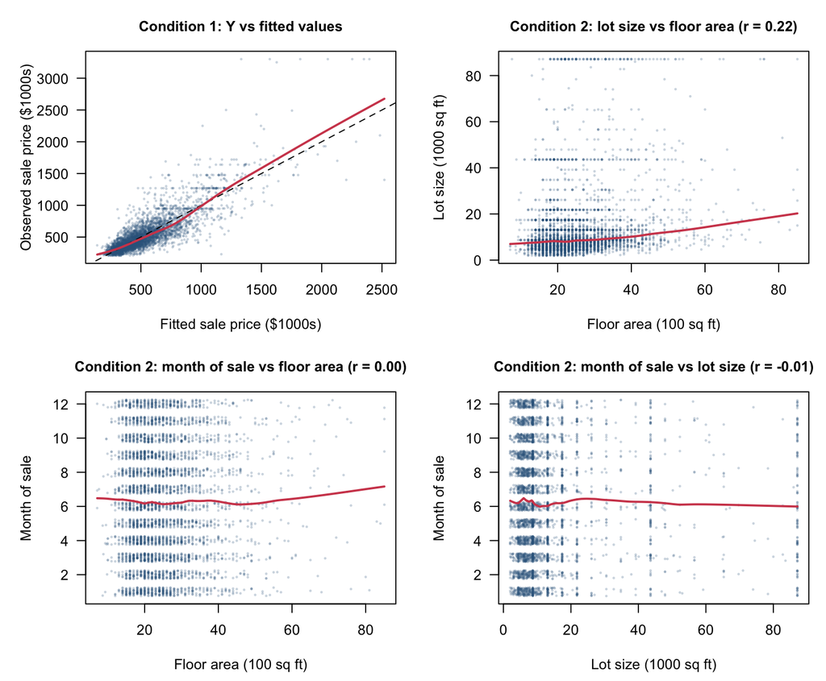

```r
draw_conditions <- function() {
  par(mfrow = c(2, 2), mar = c(4.5, 5, 3, 1), las = 1)
  plot(yhat1, train$price_k, pch = 16, cex = 0.4, col = pt_col,
       xlab = "Fitted sale price ($1000s)", ylab = "Observed sale price ($1000s)",
       main = "Condition 1: Y vs fitted values", cex.main = 1)
  abline(0, 1, lty = 2)
  lines(lowess(yhat1, train$price_k, f = 0.3), col = ln_col, lwd = 2)
  prs <- combn(num_preds, 2)
  for (j in seq_len(ncol(prs))) {
    a <- prs[1, j]; b <- prs[2, j]
    xa <- train[[a]]; xb <- train[[b]]
    if (b == "sale_month") xb <- jitter(xb, amount = 0.25)
    plot(xa, xb, pch = 16, cex = 0.4, col = pt_col, xlab = num_lab[a], ylab = num_lab[b],
         main = sprintf("Condition 2: %s vs %s (r = %.2f)", num_short[b], num_short[a],
                        cor(train[[a]], train[[b]])),
         cex.main = 1)
    lines(lowess(train[[a]], train[[b]], f = 0.3), col = ln_col, lwd = 2)
  }
}
set.seed(302)  # for the jitter of sale_month in the plot only
fig_out("fig2_conditions.png", 8, 6.6, draw_conditions)
```

```r
cor(train[, num_preds])
```

```
#>                sqft100       lot_k   sale_month
#> sqft100    1.000000000  0.21996578  0.002726099
#> lot_k      0.219965781  1.00000000 -0.011985565
#> sale_month 0.002726099 -0.01198556  1.000000000
```

## 9.2 Residuals vs fitted values, scale-location, normal QQ, and residuals vs each numerical predictor

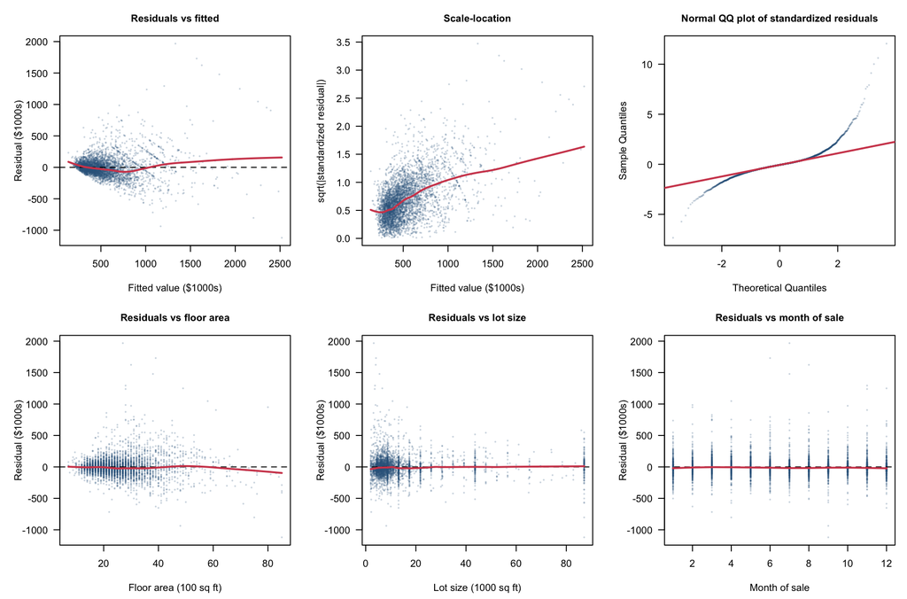

```r
draw_residuals <- function() {
  par(mfrow = c(2, 3), mar = c(4.5, 5, 3, 1), las = 1)
  plot(yhat1, e1, pch = 16, cex = 0.4, col = pt_col, xlab = "Fitted value ($1000s)",
       ylab = "Residual ($1000s)", main = "Residuals vs fitted", cex.main = 1)
  abline(h = 0, lty = 2); lines(lowess(yhat1, e1, f = 0.3), col = ln_col, lwd = 2)
  plot(yhat1, sqrt(abs(r1)), pch = 16, cex = 0.4, col = pt_col, xlab = "Fitted value ($1000s)",
       ylab = "sqrt(|standardized residual|)", main = "Scale-location", cex.main = 1)
  lines(lowess(yhat1, sqrt(abs(r1)), f = 0.3), col = ln_col, lwd = 2)
  qqnorm(r1, pch = 16, cex = 0.4, col = pt_col, main = "Normal QQ plot of standardized residuals",
         cex.main = 1)
  qqline(r1, col = ln_col, lwd = 2)
  for (v in num_preds) {
    plot(train[[v]], e1, pch = 16, cex = 0.4, col = pt_col, xlab = num_lab[v], ylab = "Residual ($1000s)",
         main = paste("Residuals vs", num_short[v]), cex.main = 1)
    abline(h = 0, lty = 2); lines(lowess(train[[v]], e1, f = 0.3), col = ln_col, lwd = 2)
  }
}
fig_out("fig3_residuals.png", 10, 6.6, draw_residuals)
```

## 9.3 Residuals by each categorical predictor

Boxes show the residual distribution in each level (whiskers at 1.5 IQR; individual outlying points are not drawn to keep the boxes readable – see the QQ plot for the tails). The title gives the ratio of the largest to the smallest residual SD across levels.

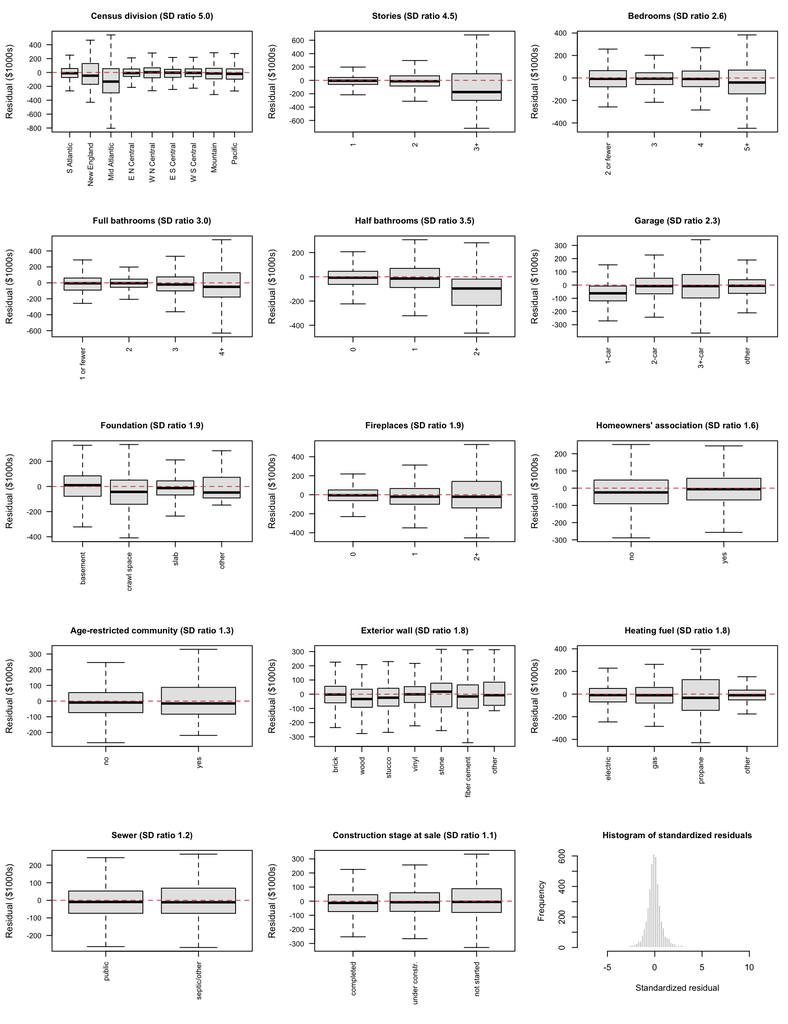

```r
sd_ratio <- sapply(cat_preds, function(v) {
  s <- tapply(e1, train[[v]], sd); max(s) / min(s)
})
draw_boxplots <- function() {
  par(mfrow = c(5, 3), mar = c(7, 5, 3, 1))
  for (v in cat_preds) {
    boxplot(e1 ~ train[[v]], names = level_lab(v), outline = FALSE, las = 2, cex.axis = 0.85, xlab = "",
            ylab = "", col = "grey90",
            main = sprintf("%s (SD ratio %.1f)", cat_lab[v], sd_ratio[v]), cex.main = 1)
    abline(h = 0, col = ln_col, lty = 2)
    mtext("Residual ($1000s)", side = 2, line = 3.6, cex = 0.7)
  }
  hist(r1, breaks = 80, col = "grey80", border = "white", xlab = "Standardized residual",
       main = "Histogram of standardized residuals", cex.main = 1)
}
fig_out("fig4_resid_by_categorical.png", 10, 13, draw_boxplots)
```

## 9.4 Numerical evidence for the assumption checks

```r
# Breusch-Pagan (Koenker, studentized) statistic computed by hand: n * R^2 of e^2 on the design matrix
bp_koenker <- function(m) {
  e2 <- resid(m)^2; X <- model.matrix(m)
  aux <- lm.fit(X, e2)
  r2 <- 1 - sum(aux$residuals^2) / sum((e2 - mean(e2))^2)
  LM <- length(e2) * r2; df <- ncol(X) - 1
  c(LM = LM, df = df, p = pchisq(LM, df, lower.tail = FALSE))
}
bp1 <- bp_koenker(m1)
lev_div <- leveneTest(y = e1, group = train$division)          # Brown-Forsythe (median-centred) version
checks <- c(cor_Y_fitted = cor(train$price_k, yhat1),
            max_abs_cor_numeric_predictors = max(abs(cor(train[, num_preds])[upper.tri(diag(3))])),
            resid_skewness = skew(e1), resid_excess_kurtosis = exkurt(e1),
            BP_LM = unname(bp1["LM"]), BP_df = unname(bp1["df"]), BP_p = unname(bp1["p"]),
            levene_division_F = lev_div[1, "F value"], levene_division_p = lev_div[1, "Pr(>F)"],
            max_sd_ratio_division = unname(sd_ratio["division"]),
            n_abs_std_resid_gt_4 = sum(abs(r1) > 4), max_abs_std_resid = max(abs(r1)))
round(checks, 4)
```

```
#>                   cor_Y_fitted max_abs_cor_numeric_predictors                 resid_skewness
#>                         0.8445                         0.2200                         2.0445
#>          resid_excess_kurtosis                          BP_LM                          BP_df
#>                        18.0050                      1280.5839                        51.0000
#>                           BP_p              levene_division_F              levene_division_p
#>                         0.0000                        62.0419                         0.0000
#>          max_sd_ratio_division           n_abs_std_resid_gt_4              max_abs_std_resid
#>                         4.9926                        36.0000                        12.0557
```

```r
round(sd_ratio, 2)
```

```
#>       division        stories       bedrooms       fullbath       halfbath         garage     foundation
#>           4.99           4.49           2.62           3.00           3.54           2.35           1.88
#>      fireplace            hoa age_restricted           wall      heat_fuel          sewer          stage
#>           1.89           1.57           1.32           1.80           1.83           1.22           1.08
```

```r
# errors across time: mean residual by sale month (a trend would suggest time dependence)
round(tapply(e1, train$sale_month, mean), 1)
```

```
#>     1     2     3     4     5     6     7     8     9    10    11    12
#> -14.2  -0.9  15.9  -1.7   3.1   8.3  -8.5  -1.2  -8.4   4.0   9.6  -8.2
```

## 9.5 Conclusions for each assumption (no corrections made in Part 1)

- **Condition 1 (Y vs fitted): approximately holds.** The observed prices scatter around a single increasing curve close to the identity line (correlation 0.84), but the spread widens sharply at high fitted values. Because both conditions hold reasonably, the residual plots can be used to diagnose which assumption fails.
- **Condition 2 (numerical predictors vs each other): holds.** The pairwise plots show no curved patterns; the largest absolute correlation among `sqft100`, `lot_k` and `sale_month` is 0.22.
- **Linearity: mildly violated.** The LOWESS curve of residuals vs fitted values is slightly U-shaped, and residuals vs `sqft100` bend away from zero at the largest floor areas. `lot_k` and `sale_month` show no systematic pattern.
- **Constant variance: clearly violated.** Residuals vs fitted values fan out (funnel shape) and the scale-location curve rises steadily. The Breusch-Pagan (Koenker) statistic is 1281 on 51 df; residual SDs differ across divisions by a factor of 5.0 (Levene p = 1.8e-96), and also across stories, bathrooms and other levels.
- **Normality: clearly violated.** The QQ plot has a long, steep upper tail; residual skewness is 2.04 and excess kurtosis 18.0, with 36 standardized residuals beyond +/-4. Part of the tail is caused by the Census top-coding of prices.
- **Uncorrelated errors: plausible by design, cannot be fully tested.** SOC is a probability sample of building permits, each row is a different house, and all rows are one cross-section (2025 contracts); the order of houses in the file is randomly scrambled within division, so a residual-vs-order plot carries no information. Residuals show no trend across sale months. The public file has no subdivision or builder identifier, so correlation among houses from the same development cannot be checked; we note this as a limitation.

These violations (right skew, heavy tail, and variance increasing with the mean) will be addressed in Part 2, for example with a Box-Cox/log transformation of price; nothing is corrected here.